# Assignment 20191007

# 1. Data installation

```r
# Download DD2GP with pLI scores
#wget https://www.dropbox.com/s/pqihpzy24yafr7c/DDG2P_24_9_2019.with_pLI.txt

# HPO
#wget https://www.dropbox.com/s/svc4rfhx2z2dopk/table.hpo_obo_20190924.txt


library(tidyverse)
library(ggplot2)
```

## 1.1 Loading Dataset

```r
ddg2p <- read_delim('DDG2P_24_9_2019.with_pLI.txt', delim = '\t', progress = show_progress())
names(ddg2p)[2] <-paste('gene_mim')
names(ddg2p)[6] <-paste('allelic_requirement')
names(ddg2p)[7] <-paste("mutation_consequence")
```

```r
ddg2p_hpo <- read_delim('table.hpo_obo_20190924.txt',delim='\t')
```

## 1.2 DATA 간략하게 살펴보기

```r
# names(ddg2p)
#  [1] "gene symbol"                  "gene_mim"                     "disease name"                 "disease mim"
#  [5] "DDD category"                 "allelic_requirement"          "mutation_consequence"         "phenotypes"
#  [9] "organ specificity list"       "pmids"                        "panel"                        "prev symbols"
# [13] "hgnc id"                      "gene disease pair entry date" "pLI"                          "pRec"
# [17] "pNull"

# str(ddg2p)
# head(ddg2p)
```

# 2 얼굴 부분만 추출.

유전적 질환 중, 다운 증후군 등, 얼굴의 표현형에 유전적 질환이 나타는 경우가 있다. 얼굴에만 나타나는 질환이 어떠한 것들이 있는지 뽑아보자.

```r
ddg2p_face <- ddg2p %>% filter(grepl("Face", ddg2p$`organ specificity list`))
col1 <- ddg2p_face %>% select(gene_mim) %>%
  mutate_if(is.character, list(~na_if(., "No gene mim")))

col1 <- col1$gene_mim %>% as.numeric()
class(col1)
```

```
[1] "numeric"
```

```r
ddg2p_face <- mutate(ddg2p_face, gene_mim = col1)

# gene_mim 항목에서, OMIM 을 기준으로, 어디에 있는 유전자인지를 확인한다.

ddg2p_face <- ddg2p_face %>%
    mutate(OMIM = case_when(
    gene_mim>=100000 & gene_mim <300000 ~ "Autosomal",
    gene_mim>=300000 & gene_mim <400000 ~ "X-linked",
    gene_mim>=400000 & gene_mim <500000 ~ "Y-linked",
    gene_mim>=500000 & gene_mim <600000 ~ "Mitochondrial",
    gene_mim>=600000 ~ "Autosomal",
    TRUE ~ "others"))
table(ddg2p_face$OMIM)
```

```
Autosomal    others  X-linked
      220         1        40
```

# 2.1 Simply check the dataset

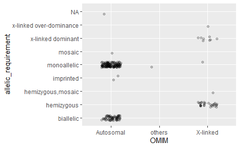

```r
ddg2p_face %>%
  ggplot(aes(OMIM, allelic_requirement)) +
  geom_jitter(width = 0.2, height = 0.2, alpha = 0.2)
```

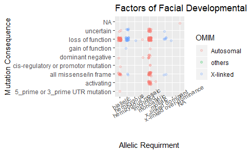

```r
plot1 <- ddg2p_face %>%
  ggplot(aes(allelic_requirement, mutation_consequence, color = OMIM)) +
  geom_jitter(width = 0.2, height = 0.2, alpha = 0.2) +
  theme(axis.text.x = element_text(angle = 30)) +
  labs(x= 'Allelic Requirment', y ='Mutation Consequence', title ='Factors of Facial Developmental disorders')

ggsave('plot.DDG2P.genetic_face_disorder.png', plot1)
plot1
```

```r
plot2 <- ddg2p %>%
  ggplot(aes(allelic_requirement, mutation_consequence, color = OMIM)) +
  geom_jitter(width = 0.2, height = 0.2, alpha = 0.1) +
  theme(axis.text.x = element_text(angle = 30)) +
  labs(x= 'Allelic Requirment', y ='Mutation Consequence', title ='Factors of Every Developmental disorders')
```

`\n` 입력하면

cis-regulatory or promotor mutation -> cis-regulatory promotor mutation 이렇게 2줄로 나눌 수 있다.

**modify xy ggplot** googling 하자.

```r
# scale_x_discrete
# scale_x_continuos
```

```r
ddg2p <- as.tibble(ddg2p)
col1 <- ddg2p%>% select(gene_mim) %>%
  mutate_if(is.character, list(~na_if(., "No gene mim")))

names(ddg2p)[2] <-paste('gene_mim')
names(ddg2p)[6] <-paste('allelic_requirement')
names(ddg2p)[7] <-paste("mutation_consequence")

ddg2p <- mutate(ddg2p, gene_mim = as.numeric(gene_mim))

ddg2p <- ddg2p %>%
    mutate(OMIM = case_when(
    gene_mim>=100000 & gene_mim <300000 ~ "Autosomal",
    gene_mim>=300000 & gene_mim <400000 ~ "X-linked",
    gene_mim>=400000 & gene_mim <500000 ~ "Y-linked",
    gene_mim>=500000 & gene_mim <600000 ~ "Mitochondrial",
    gene_mim>=600000 ~ "Autosomal",
    TRUE ~ "others"))
table(ddg2p$OMIM)
```

```
Autosomal    others  X-linked  Y-linked
     2142        17       221         1
```

```r
# plot1 + plot2 같은 pdf에 넣기

library(cowplot)
p3 <- plot_grid(plot1, plot2, ncol =1)
```

```
Error in FUN(X[[i]], ...) : object 'OMIM' not found
```

```r
# bind_rows(d_luad %>%
#             mutate(type='luad') %>%
#             select(type, shortLetterCode, tumor_stage),
#           d_lusc %>%
#             mutate(type='lusc') %>%
#             select(type, shortLetterCode, tumor_stage)) %>%
#   count(shortLetterCode, type) %>%
#   complete(type, shortLetterCode, fill = list(n = 0)) %>% # Q1: What is this?
#   ggplot(., aes(shortLetterCode, n, fill=shortLetterCode)) +
#   geom_bar(stat="identity", position=position_dodge()) +
#   facet_wrap(~type, scales = 'free_x', ncol=5) # Q2: What is this?


ddg2p <- read_delim('DDG2P_24_9_2019.with_pLI.txt', delim = '\t', progress = show_progress())
names(ddg2p)[2] <-paste('gene_mim')
names(ddg2p)[6] <-paste('allelic_requirement')
names(ddg2p)[7] <-paste("mutation_consequence")

ddg2p <- ddg2p %>%
  mutate(facial_disorder =
           if_else(grepl("Face", ddg2p$`organ specificity list`),
                   "facial",
                   "non_facial")) %>%
  mutate(facial_disorder = as.factor(facial_disorder))


col2 <- ddg2p %>% select(gene_mim) %>%
  mutate_if(is.character, list(~na_if(., "No gene mim"))) %>% pull()

ddg2p <- ddg2p %>% mutate(gene_mim = col2)

ddg2p <- ddg2p %>% mutate(gene_mim = as.numeric(gene_mim))

ddg2p <- ddg2p %>%
    mutate(OMIM = case_when(
    gene_mim>=100000 & gene_mim <300000 ~ "Autosomal",
    gene_mim>=300000 & gene_mim <400000 ~ "X-linked",
    gene_mim>=400000 & gene_mim <500000 ~ "Y-linked",
    gene_mim>=500000 & gene_mim <600000 ~ "Mitochondrial",
    gene_mim>=600000 ~ "Autosomal",
    TRUE ~ "others"))


ddg2p <- ddg2p %>% mutate(OMIM = as.factor(OMIM))
ddg2p <- ddg2p %>% mutate(facial_disorder = as.factor(facial_disorder))
```

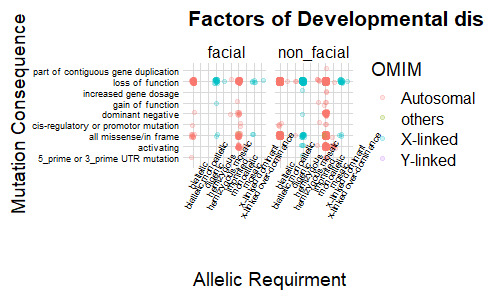

```r
# plot1 <- ddg2p_face %>%
#   ggplot(aes(allelic_requirement, mutation_consequence, color = OMIM)) +
#   geom_jitter(width = 0.2, height = 0.2, alpha = 0.2) +
#   theme(axis.text.x = element_text(angle = 30)) +
#   labs(x= 'Allelic Requirment', y ='Mutation Consequence', title ='Factors of Facial Developmental disorders')

# plot2 <- ddg2p %>%
#   ggplot(aes(allelic_requirement, mutation_consequence, color = OMIM)) +
#   geom_jitter(width = 0.2, height = 0.2, alpha = 0.1) +
#   theme(axis.text.x = element_text(angle = 30)) +
#   labs(x= 'Allelic Requirment', y ='Mutation Consequence', title ='Factors of Every Developmental disorders')

plot4 <- ddg2p %>%
  filter(mutation_consequence != 'NA' & mutation_consequence != 'uncertain') %>%
  ggplot(aes(allelic_requirement, mutation_consequence, color = OMIM)) +
  geom_jitter(width = 0.2, height = 0.2, alpha = 0.2) +
  labs(x= 'Allelic Requirment', y ='Mutation Consequence', title ='Factors of Developmental disorders') +
  facet_grid(~facial_disorder) +
  theme_minimal_grid() +
  theme(axis.text.x = element_text(angle = 60, size =7), axis.text = element_text(size = 7))

plot4

ggsave('plot.ddg2p.factors_of_developmental_disorders.20191007.pdf', plot4, width = 10)
```

```r
# saving phenotype
phenotypes <- as.tibble(ddg2p_face$phenotypes)

library(splitstackshape)
phenotypes <- cSplit(phenotypes, "value", sep=";", type.convert = FALSE)
```

`phenotypes` 는 wide to long format 검색해서 바꿔주자.

# 1. 얼굴의 유전병 분석

유전병 인자는 인체의 다양한 부위에 영향을 준다. DDG2P 데이터에서 `organ specificity list` 를 보면 하나의 유전인자가 하나 이상의 부위에 영향을 줌을 알 수 있다. 유전자들 중에 얼굴의 표현형에 영향을 주는 인자가 무엇인지 알아보고, 이들이 어떤 특성을 가지는지 분석하겠다.

## 1.1 데이터 준비

```r
# Download DD2GP with pLI scores
#wget https://www.dropbox.com/s/pqihpzy24yafr7c/DDG2P_24_9_2019.with_pLI.txt

# HPO
#wget https://www.dropbox.com/s/svc4rfhx2z2dopk/table.hpo_obo_20190924.txt


library(tidyverse)
library(ggplot2)
library(ggthemes)

ddg2p <- read_delim('DDG2P_24_9_2019.with_pLI.txt', delim = '\t', progress = F)
names(ddg2p)[2] <-paste('gene_mim')
names(ddg2p)[6] <-paste('allelic_requirement')
names(ddg2p)[7] <-paste("mutation_consequence")

ddg2p_hpo <- read_delim('table.hpo_obo_20190924.txt',delim='\t')
```

어느 염색체에 있는 유전자인지도 중요한 지표이다. 어떤 염색체에 속한 유전자인지 알기 위해 Wikipedia의 [Online Mendelian Inheritance in Man](https://en.wikipedia.org/wiki/Online_Mendelian_Inheritance_in_Man) 문서를 참고하였다.

```r
col1 <- ddg2p %>% select(gene_mim) %>%
  mutate_if(is.character, list(~na_if(., "No gene mim")))

col1 <- col1$gene_mim %>% as.numeric()

ddg2p <- mutate(ddg2p, gene_mim = col1)

ddg2p <- ddg2p %>%
      mutate(OMIM = case_when(
    gene_mim>=100000 & gene_mim <300000 ~ "Autosomal",
    gene_mim>=300000 & gene_mim <400000 ~ "X-linked",
    gene_mim>=400000 & gene_mim <500000 ~ "Y-linked",
    gene_mim>=500000 & gene_mim <600000 ~ "Mitochondrial",
    gene_mim>=600000 ~ "Autosomal",
    TRUE ~ "others"))

ddg2p <- ddg2p %>% mutate(OMIM = as.factor(OMIM))

table(ddg2p$OMIM)
```

또한, 얼굴에 대한 표현형을 가지고 있는 유전자만을 따로 표시한다.

```r
ddg2p <- ddg2p %>%
  mutate(facial_disorder =
           if_else(grepl("Face", ddg2p$`organ specificity list`),
                   "facial",
                   "non_facial")) %>%
  mutate(facial_disorder = as.factor(facial_disorder))

ddg2p <- ddg2p %>% mutate(facial_disorder = as.factor(facial_disorder))
ddg2p <- ddg2p %>% mutate(allelic_requirement = as.factor(allelic_requirement))
ddg2p <- ddg2p %>% mutate(mutation_consequence = as.factor(mutation_consequence))
```

# 2. 데이터 관찰

## 2.1 `muation_consequence` 관찰

전체 게놈의 `mutation_consequence`를 보도록 하자.

```r
# 그래프 그리기 전 기초 작업

levels(ddg2p$mutation_consequence) <- gsub("5_prime or 3_prime UTR mutation", "5' or 3' UTR mutation",levels(ddg2p$mutation_consequence))

levels(ddg2p$mutation_consequence) <- gsub("cis-regulatory or promotor mutation", "cis-regulatory or \n promotor mutation",levels(ddg2p$mutation_consequence))

levels(ddg2p$mutation_consequence) <- gsub("part of contiguous gene duplication", "part of contiguous \n gene duplication",levels(ddg2p$mutation_consequence))

# 그래프에 넣을 정확한 값 입력

n_mc<- ddg2p %>%
  count(mutation_consequence)

# 그래프 그려 확인
ddg2p %>%
  count(mutation_consequence) %>%
  ggplot(aes(mutation_consequence, n, fill = mutation_consequence)) +
  geom_bar(stat="identity", position = position_dodge(width = 2)) +
  theme_bw() +
  coord_flip() +
  theme(legend.title = element_blank(), legend.position = "none") +
  xlab("Mutation Consequence") +
  ylab("Counts") +
  geom_text(aes(x = mutation_consequence, y=n_mc$n, label = round(n_mc$n, 2)))
```

[output not shown]

바로 이어 얼굴에 대해서도 살펴보자.

```r
# 그래프에 넣을 정확한 값 입력

n_mc<- ddg2p %>%
  count(mutation_consequence) %>%
  filter(mutation_consequence != "NA") %>%
  mutate(ratio = n/sum(n))

n_f_mc <- ddg2p %>%
  filter(facial_disorder == "facial") %>%
  count(mutation_consequence) %>%
  filter(mutation_consequence != "NA") %>%
  mutate(ratio = n/sum(n))

# 그래프 그려 확인
ddg2p %>%
  filter(facial_disorder == "facial", mutation_consequence != "NA") %>%
  count(mutation_consequence) %>%
  ggplot(aes(mutation_consequence, n, fill = mutation_consequence)) +
  geom_bar(stat="identity", position = position_dodge(width = 2)) +
  theme_bw() +
  coord_flip() +
  theme(legend.title = element_blank(), legend.position = "none") +
  labs(x = "Mutation Consequence", y ="Counts", title = "Mutation Consequences for Facial Disorder") +
  geom_text(aes(x = mutation_consequence, y = n_f_mc$n, label = round(n_f_mc$n, 2)))
```

[output not shown]

Facial Disorder 와 Non Facial Disorder 의 차이를 비교하겠다.

```r
# 우선 얼굴 유전 질환 데이터들만 추출한다.
ddg2p_face <- ddg2p %>%
  filter(facial_disorder == "facial")

# 두 데이터를 비교하겠다.
p1 <- bind_rows(ddg2p %>%
            filter(.,mutation_consequence != is.na(mutation_consequence)) %>%
            mutate(type='Whole') %>%
            count(mutation_consequence, type) %>%
            mutate(ratio = n/sum(n)) %>%
            select(type, mutation_consequence, n, ratio),
          ddg2p_face %>%
            filter(.,mutation_consequence != is.na(mutation_consequence)) %>%
            mutate(type='Facial') %>%
            count(mutation_consequence, type) %>%
            mutate(ratio = n/sum(n)) %>%
            select(type, mutation_consequence, n, ratio)) %>%
  complete(type, mutation_consequence, fill = list(n=0)) %>%
  complete(type, mutation_consequence, fill = list(ratio=0)) %>%
  ggplot(aes(mutation_consequence, ratio, fill = mutation_consequence)) +
  geom_bar(stat="identity", position = position_dodge(width = 2)) +
  theme_bw() +
  coord_flip() +
  theme(legend.title = element_blank(), legend.position = "none") +
  geom_text(aes(x = mutation_consequence, y = ratio, label = round(ratio, 2))) +
  facet_wrap(. ~ type) +
  labs(x = "Mutation Consequence", y = "Ratio", title ="Comparison between Whole and Facial Mutation Consequences")

p1

ggsave("plot.ddg2p.comparison_whole_facial_mutation_consequence.20191015.png", p1)
```

[output not shown]

## 2.2 `allelic_requirement` 관찰

위와 비슷한 방식으로 allelic requirement 를 살펴보자.

```r
# 비교 데이터 생성.
d <- bind_rows(ddg2p %>%
            mutate(type='Whole') %>%
            filter(.,allelic_requirement != is.na(allelic_requirement)) %>%
            count(allelic_requirement, type) %>%
            mutate(ratio = n/sum(n)) %>%
            select(type, allelic_requirement, n, ratio),
          ddg2p_face %>%
            mutate(type='Facial') %>%
            filter(.,allelic_requirement != is.na(allelic_requirement)) %>%
            count(allelic_requirement, type) %>%
            mutate(ratio = n/sum(n)) %>%
            select(type, allelic_requirement, n, ratio)) %>%
  complete(type, allelic_requirement, fill = list(ratio = 0)) %>%
  complete(type, allelic_requirement, fill = list(n=0))

ind <- c(10, 9, 5, 8, 4, 3, 6, 2, 1, 7)

d$allelic_requirement <- factor(d$allelic_requirement, levels = d$allelic_requirement[ind])

d %>% ggplot(aes(allelic_requirement, ratio, fill = allelic_requirement)) +
  geom_bar(stat="identity", position = position_dodge(width = 2)) +
  coord_flip() +
  geom_text(aes(x = allelic_requirement, y = ratio/1.5 + 0.05, label = round(ratio, 3))) +
  geom_text(aes(x = allelic_requirement, y = 0.68, label = n)) +
  geom_text(aes(x = allelic_requirement, y = 0.68, label ='(        )' )) +
  geom_text(aes(x = allelic_requirement, y = 0.73, label ='' ), color = "blue") +
  facet_wrap(. ~ type) +
  labs(x = "Allelic Requirement",
      y = "Ratio, (Counts)",
      title ="Comparison between Whole and Facial Allelic Requirement",
      caption = "Data source: The Development Disorder Genotype - Phenotype Database") +
  theme_bw() +
  theme(legend.title = element_blank(), legend.position = "none",
        plot.title = element_text(hjust = 0),
        plot.caption = element_text(hjust = 0))

# p2
# ggsave("plot.ddg2p.comparison_whole_facial_allelic_requirement.20191015.png", p2)
```

[output not shown]

```r
df <- d[1:10,] %>% mutate(face_ratio = ratio) %>% select(allelic_requirement, face_ratio)
dw <- d[11:20,] %>% mutate(whole_ratio = ratio) %>% select(whole_ratio)
dc <- cbind(df, dw) %>% mutate(ratio_comparison = face_ratio - whole_ratio)
dc %>%
  ggplot(aes(allelic_requirement,ratio_comparison, fill = allelic_requirement)) +
  geom_bar(stat='identity') +
  theme_bw() +
  coord_flip() +
  geom_text(aes(x = allelic_requirement,y = ratio_comparison/1.3, label = round(ratio_comparison,5)))+
  labs(y = "Ratio Comparison (Absolute Difference in Value)",
      x = "Allelic Requirement",
      title = "Ratio Comparison: Facial - Whole",
      caption = "Data source: The Development Disorder Genotype - Phenotype Database") +
  theme(legend.title = element_blank(), legend.position = "none",
        plot.title = element_text(hjust = 0),
        plot.caption = element_text(hjust = 0))
```

[output not shown]

## 2.3 OMIM 에 따른 분석

앞의 **1.1** 에서 나누었던 OMIM 을 살펴보자.

```r
table(ddg2p_face$OMIM)

filter(ddg2p_face, OMIM == "others") %>%
  select('gene symbol', gene_mim, allelic_requirement, mutation_consequence)
```

[output not shown]

```r
 ddg2p_face %>%
  filter(OMIM != "others") %>%
  filter(mutation_consequence != "NA") %>%
  count(mutation_consequence, OMIM) %>%
  mutate(ratio = n/sum(n)) %>%
  ggplot(aes(mutation_consequence, ratio, fill = OMIM)) +
  geom_bar(stat="identity", position = position_dodge()) +
  theme_bw() +
  coord_flip() +
  geom_text(aes(x = mutation_consequence, y = ratio, label = round(n, 2))) +
  labs(x = "Mutation Consequence", y = "counts", title = "Mutation Consequence VS OMIM at Facial Genetic Disorder")
```

[output not shown]

## 2.4 Mono- or Biallelic Requirement 분석

**2.2** 에서 **Allelic Requirement**에서 monoallelic, biallelic genetic disordr 가 유의미한 차이를 갖는 것을 보았다. 이 두 항목에 대해 OMIM 을 살펴보기로 하자.

```r
ddg2p_face %>%
  filter(allelic_requirement == 'monoallelic'| allelic_requirement == 'biallelic') %>% select(OMIM) %>% table
ddg2p_face %>%
  filter(OMIM == "others" | OMIM == "X-linked") %>%
  filter(allelic_requirement == 'monoallelic'| allelic_requirement == 'biallelic') %>%
  select('gene symbol', OMIM, gene_mim, allelic_requirement, mutation_consequence)
```

[output not shown]

facial data에서,**Allelic Requirement** 가 `monoallelic`과 `biallelic` 인 row 만 추출하고, 상염색체에 존재하는 유전자들에 대해서 **Mutation Consequence** 가 어떻게 다른지 살펴보겠다.

```r
ddg2p_face %>% filter(allelic_requirement == 'monoallelic'| allelic_requirement == 'biallelic' & allelic_requirement !=is.na(allelic_requirement)) %>%
  filter(OMIM == "Autosomal") %>%
  filter(mutation_consequence != "NA") %>%
  group_by(allelic_requirement) %>%
  count(mutation_consequence, OMIM) %>%
  mutate(ratio = n/sum(n)) %>%
  ggplot(aes(mutation_consequence, ratio, fill = mutation_consequence)) +
  geom_bar(stat="identity", position = position_dodge()) +
  theme_bw() +
  theme(legend.title = element_blank(), legend.position = "none") +
  coord_flip() +
  geom_text(aes(x = mutation_consequence, y = ratio, label = round(ratio, 5))) +
  labs(x = "Mutation Consequence", y = "Count") +
  facet_grid(. ~ allelic_requirement)
```

[output not shown]

전체 유전자 데이터에서도 상염색체에 존재하는 유전자를 분석하겠다.

```r
ddg2p %>% filter(allelic_requirement == 'monoallelic'| allelic_requirement == 'biallelic') %>%
  filter(OMIM == "Autosomal") %>%
  filter(mutation_consequence != "NA") %>%
  group_by(allelic_requirement) %>%
  count(mutation_consequence, OMIM) %>%
  mutate(ratio = n/sum(n)) %>%
  ggplot(aes(mutation_consequence, ratio, fill = mutation_consequence)) +
  geom_bar(stat="identity", position = position_dodge()) +
  theme_bw() +
  theme(legend.title = element_blank(), legend.position = "none") +
  coord_flip() +
  geom_text(aes(x = mutation_consequence, y = ratio, label = round(ratio, 5))) +
  labs(x = "Mutation Consequence", y = "Count") +
  facet_grid(. ~ allelic_requirement)
```

[output not shown]

```r
ddg2p %>%
  filter(mutation_consequence != 'NA' & mutation_consequence != 'uncertain') %>%
  group_by(facial_disorder, OMIM) %>%
  count(mutation_consequence, allelic_requirement)

ddg2p %>%
  filter(mutation_consequence != 'NA' & mutation_consequence != 'uncertain') %>%
  group_by(facial_disorder, OMIM) %>%
  count(mutation_consequence, allelic_requirement) %>%
  ggplot(aes(allelic_requirement, mutation_consequence, color = OMIM)) +
  geom_jitter(width = 0.2, height = 0.2, alpha = 0.2) +
  labs(x= 'Allelic Requirment', y ='Mutation Consequence', title ='Factors of Developmental disorders') +
  facet_grid(~facial_disorder) +
  theme(axis.text.x = element_text(angle = 60, size =7), axis.text = element_text(size = 7))
  geom_text(aes(x = allelic_requirement, y = mutation_consequence, label = round(n, 2)))
```